# MA304 Coursework Assignment

# A Closer Look: Misdemeanor Crime in Dallas

We can map the location of Misdemeanor offenses in Dallas below.

[interactive chart not shown]

From the map above we can see that APOWW are most common in the city centre and in the eastern regions. Evading/Resisting Arrest is similarly most common central Dallas and in the east. Public Intoxication is largely concentrated in the city centre then scattered evenly to the outskirts of the city. Resisting Search/Transport is more or less spread evenly throughout the city with a slight increase in the city centre.

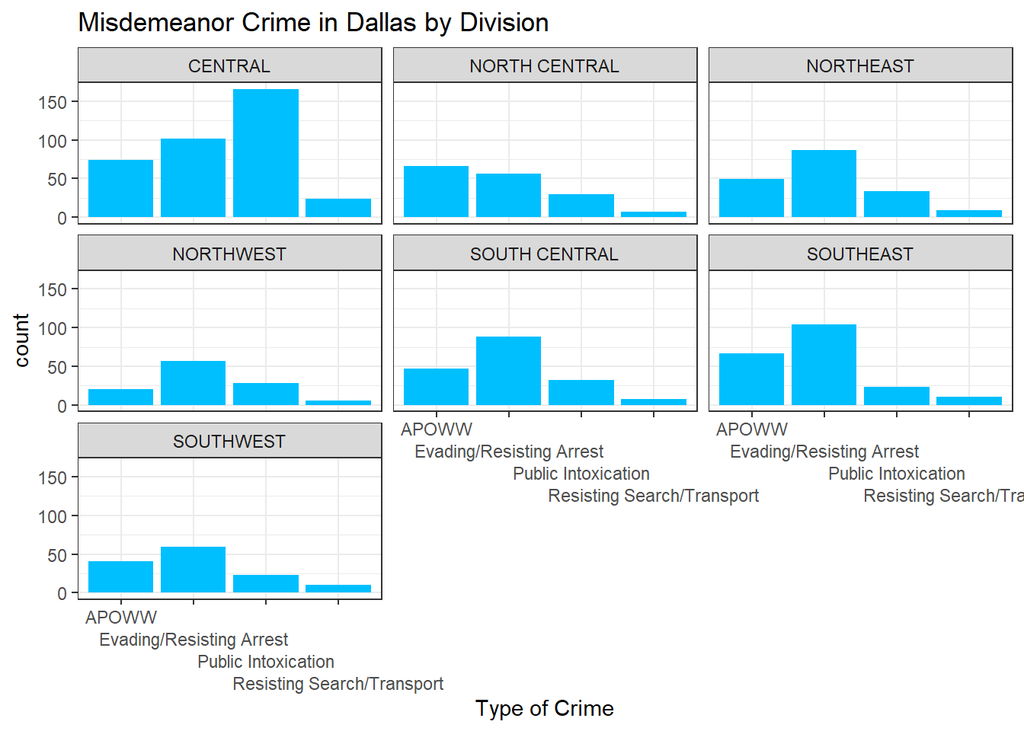

From the plot above we can see that APOWW is most common in the central divisions and eastern divisions (CENTRAL, NORTH CENTRAL, SOUTH CENTRAL, NORTHEAST and SOUTHEAST) and less common in the western divisions (NORTHWEST and SOUTHWEST). For Evading/Resisting Arrest it is similarly more common in the central divisions and eastern divisions (CENTRAL, SOUTH CENTRAL, NORTHEAST and SOUTHEAST). For Public Intoxication it is by far most common in the central division (CENTRAL) and the remaining counts spread evenly across the different divisions (NORTHWEST, SOUTHWEST, NORTH CENTRAL, SOUTH CENTRAL, NORTHEAST and SOUTHEAST). For Resisting Search/Transport it is more or less spread evenly across all the different divisions but with a slight increase in the CENTRAL division.

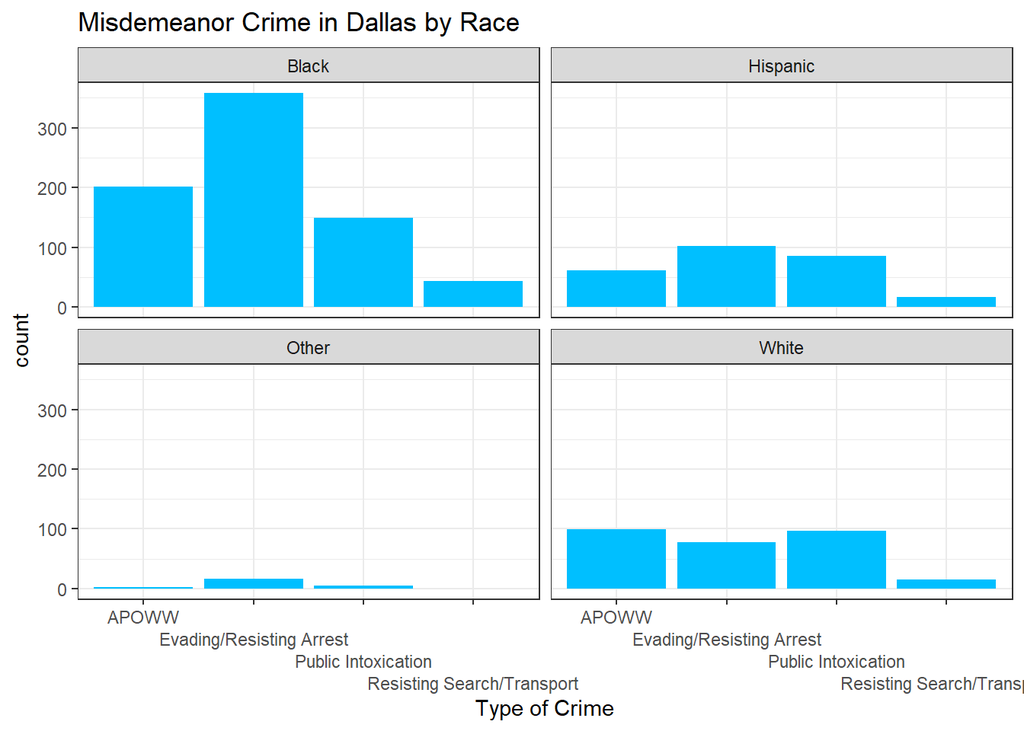

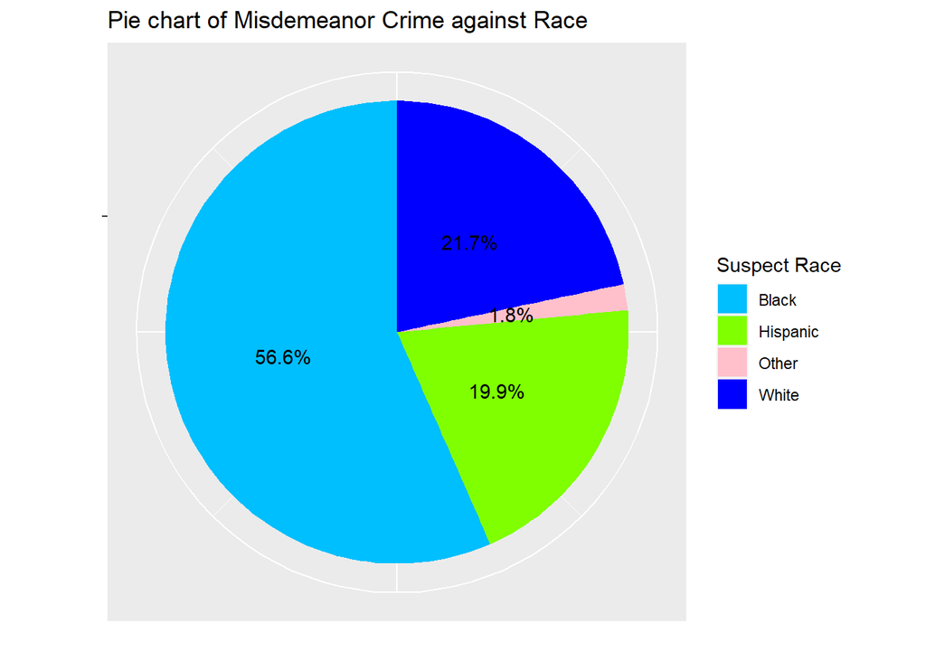

From the pie chart above we can see that Black suspects have the biggest count of Misdemeanor Crime proportionally at 56.6% with White and Hispanic suspects at 21.7% and 19.9% respectively with Other at 1.8%.

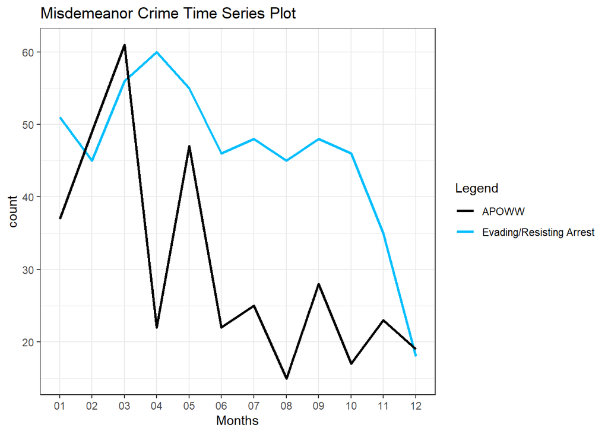

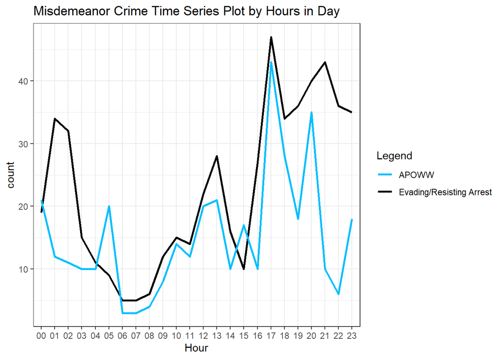

From the time series plot above we can see that for APOWW it is most common in the evening at 17:00 and early in the morning, afternoon and having smaller peaks at 05:00, 13:00 and 20:00 it is also least common early in the morning having its smallest peak early in the morning at 06:00. For Evading/Resisting Arrest it is most common similarly to APOWW in the evening at 17:00 and late at night and in the afternoon having smaller peaks at 01:00, 13:00 and 21:00. Evading/Resisting Arrest is least common early in the morning at 06:00 and in the morning and afternoon at 11:00 and 15:00.

# Discrimination in Policing

To look for any potential discrimination and bias in policing I will look at the non-arrested suspects and look at the reason for the call-out, suspect description, police response and other factors to evaluate if there was any potential bias.

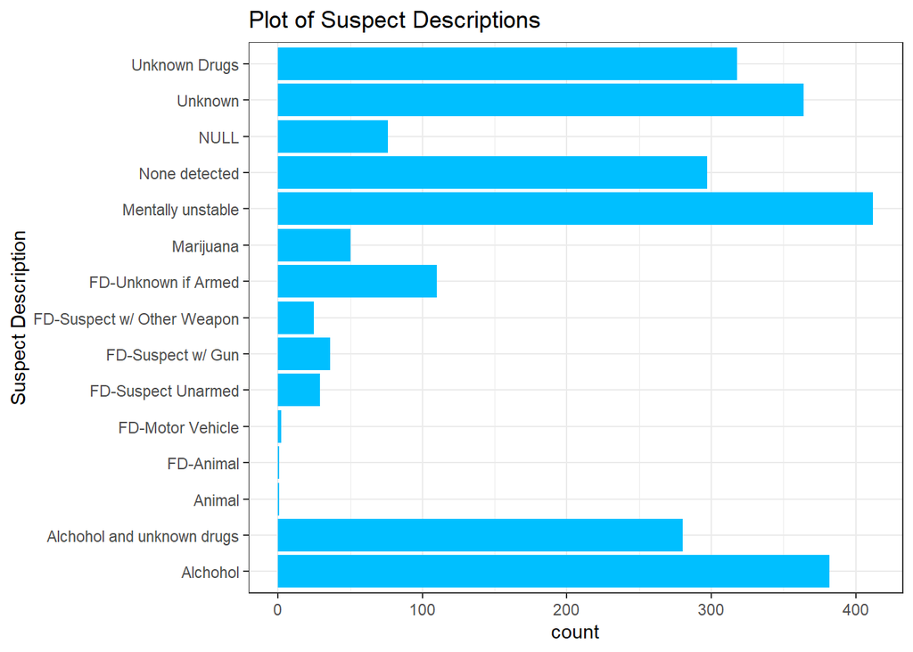

From the plot above we can see that the largest types of suspect description are Mentally Unstable, Alcohol and Unknown. The next three most frequent descriptions are Unknown Drugs, None Detected and Alcohol and Unknown Drugs with the rest of the descriptions being considerable less frequent.

We can split the plot above against the suspects who were arrested and not arrested to see if there is any difference in suspect descriptions.

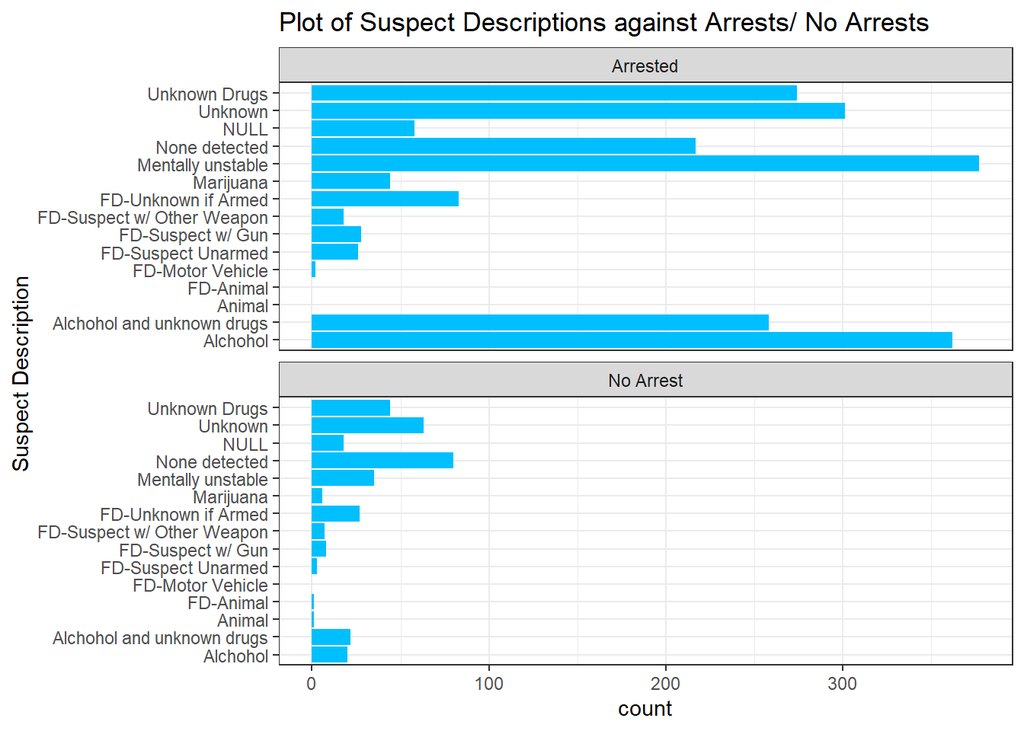

From the plot above we can see that the suspects who were not arrested the largest count of suspect description was None Detected, Unknown and Unknown Drugs compared to those that were arrested which have Mentally Unstable, Alcohol and Unknown as the biggest descriptions. We can pair this information for the Incident Reason to look for any correlation.

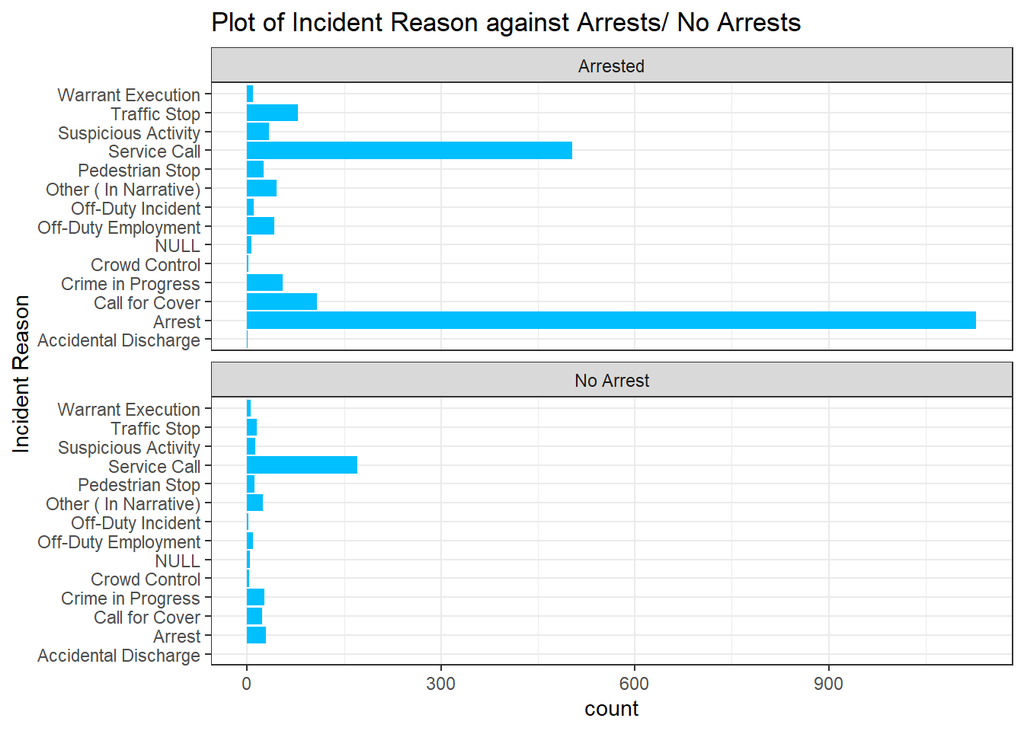

From the plot above we can see that for the No Arrest subplot the biggest Incident Reason was for a Service Call. We can break down the Service Call incident reason by race.

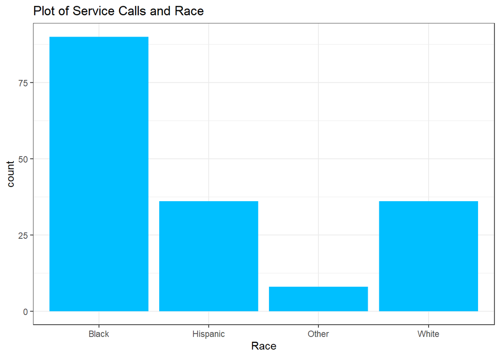

From the plot above we can see that Black suspects have the highest count of Service Call incidents with the police with Hispanic and White suspects having tied second and Other at last.

Since citizens make the service calls to the police we cannot gather any more information from “Service Calls” to look for any potential discrimination by the police. We can look more specifically into Traffic Stops and Pedestrian Stops to see if there is any potential bias and discrimination when searching potential suspects.

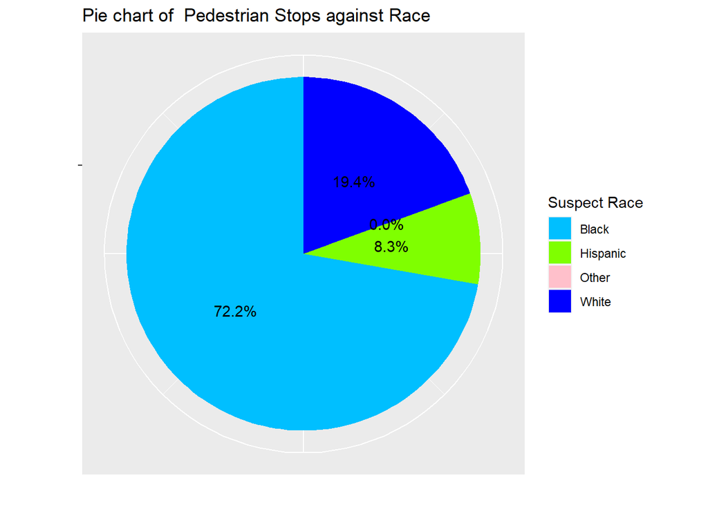

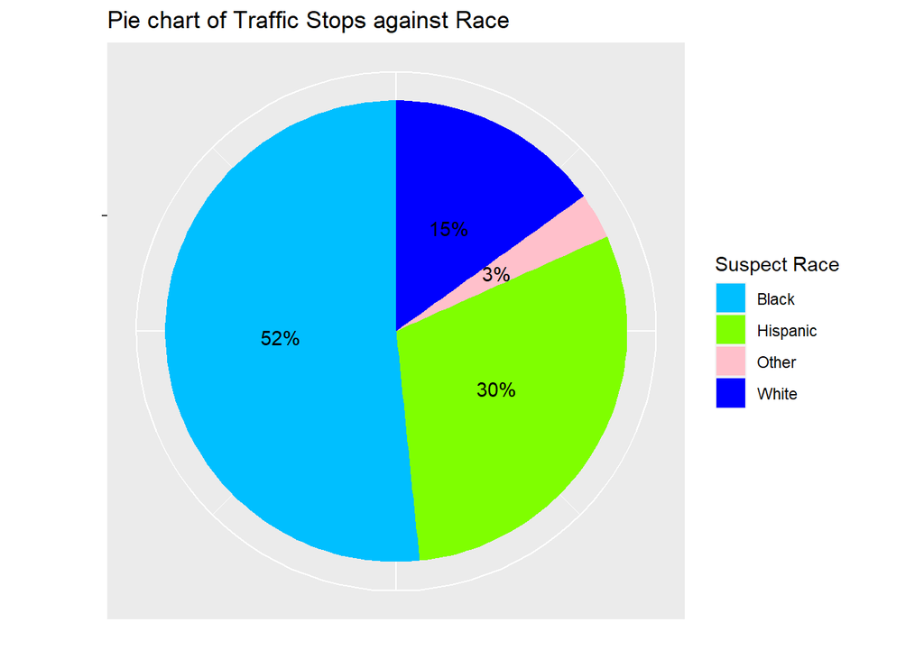

From the pie charts above we can see that Black suspects are disproportionately more likely to be stopped and searched compared to other races. We can go into more depth since the plots above do not differentiate the suspects that were arrested and not arrested.

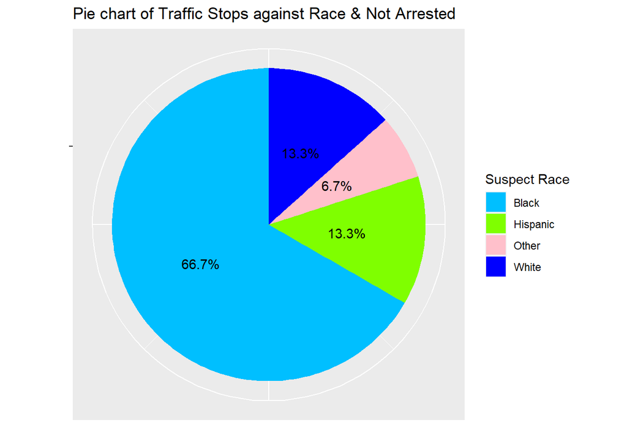

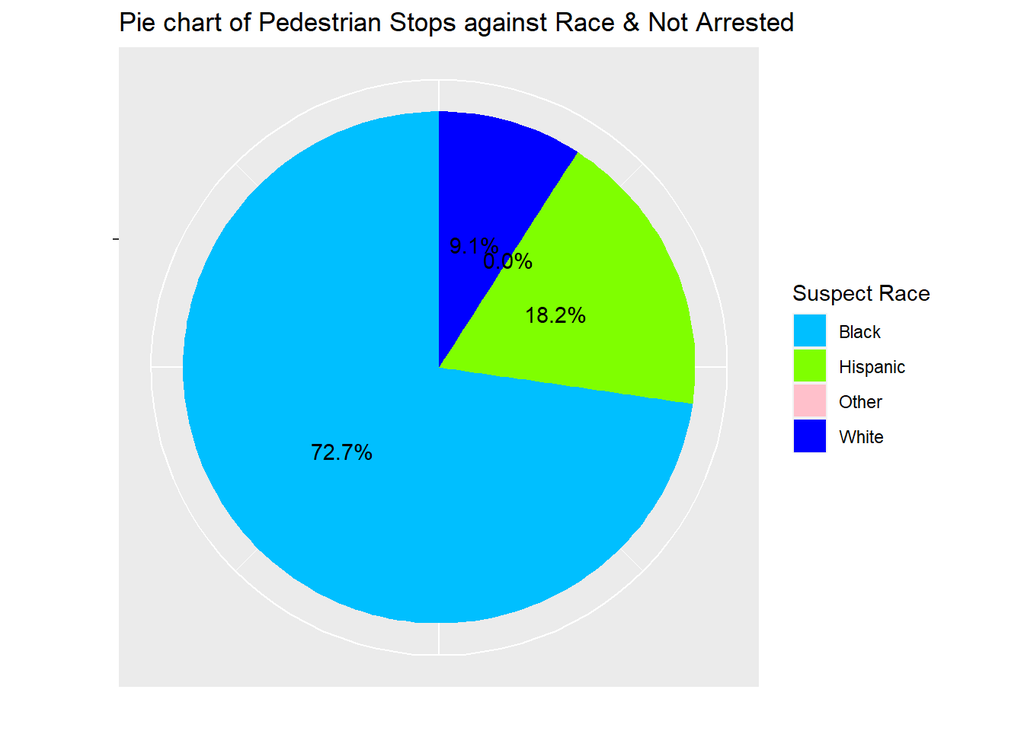

After factoring in whether the suspects that were arrested or not the pattern is still the same that Black suspects are still searched considerable more compared to White and Hispanic suspects.

# Use of Force Incidents in Dallas

In this section I will look at the Use of Force (UOF) by police officers in Dallas. I have broken down the different types of UOF by **Unarmed Response** and **Armed Response**. Unarmed Response will include Takedown, Strikes, Joint Locks etc… and Armed Response will include a variety of less than lethal responses such as Pepper Spray, Taser etc… I will analyse this information against a variety of different factors such as suspect race, crime, location etc…

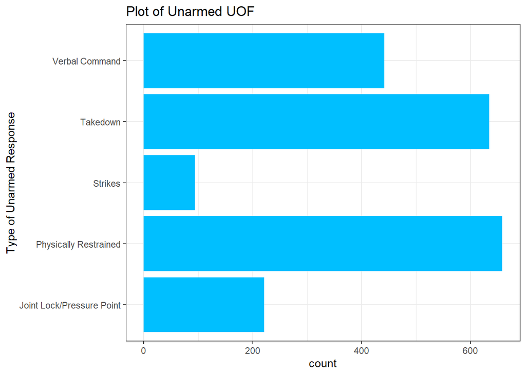

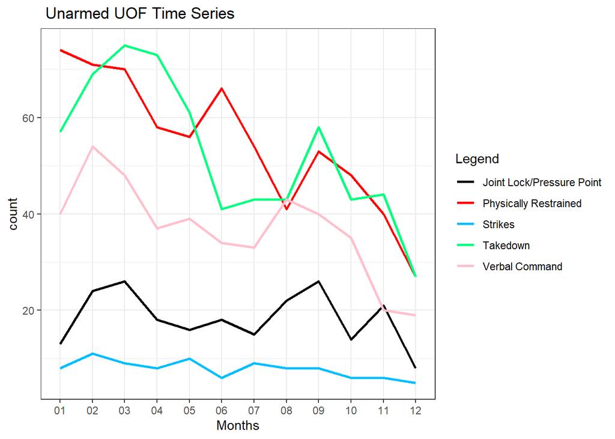

From the bar plot above we can see that Physically Restrained is the highest count of unarmed UOF being closely followed by Takedown with Verbal Command and Joint Lock/Pressure Point in third and fourth place with Strikes in last. From the time series plot above we can see that similarly to the bar plot above that Physically Restrained and Takedown have the highest count with the general trend of it being decreasing similar to the trend of the incidents throughout the year.

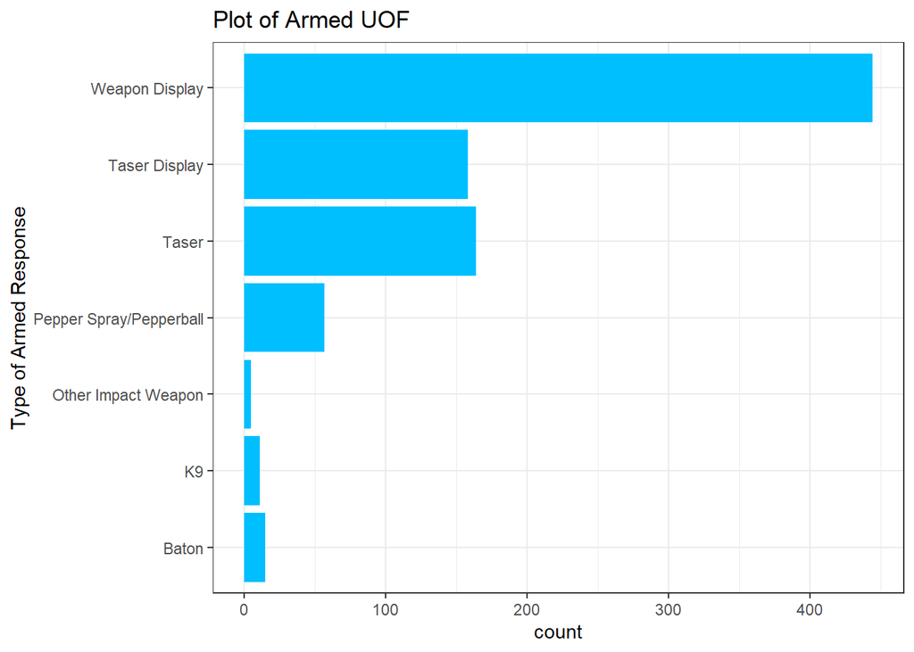

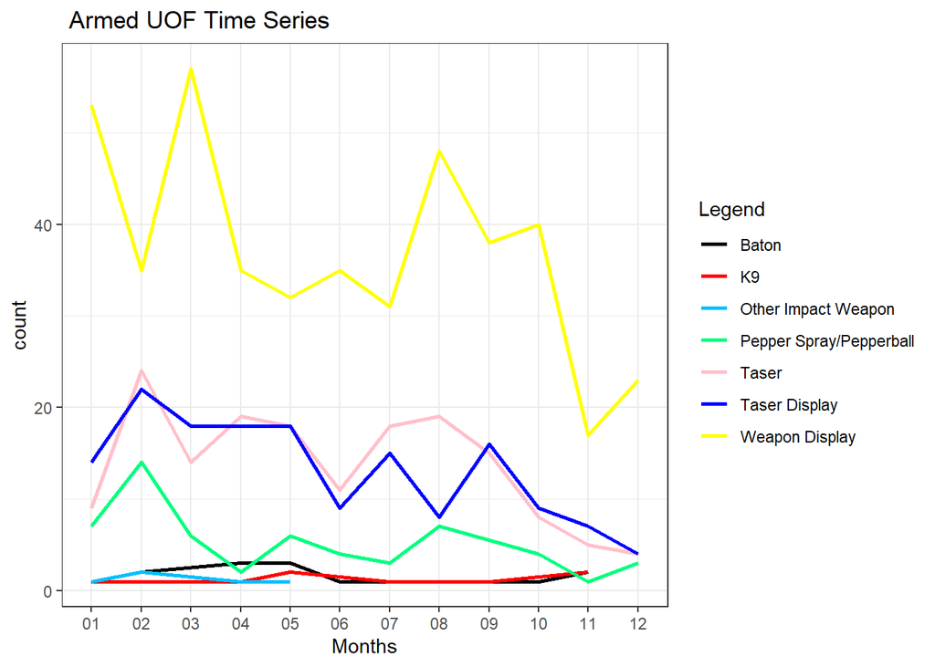

From the bar plot above we can see that Weapon Display is by far the most common type of Armed UOF is Weapon Display with Taser and Taser Display being nearly tied in second and third place and Pepper Spray/Pepperball in fourth place with the other UOF types being in negligible amounts. From the time series plot above we can see that Weapon Display is the highest type of Armed UOF followed by Taser and Taser Display and Pepper Spray/Pepperball with the remaining tactics being too infrequent.

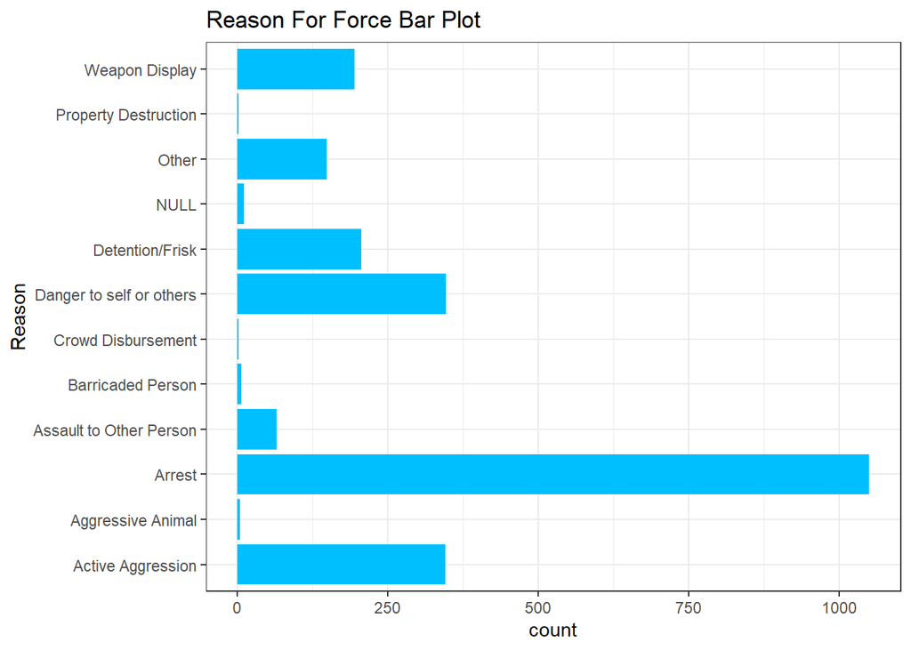

From the bar plot above we can see that the biggest reason for UOF was Arrest, Danger to self or others and Active Aggression.

[interactive chart not shown]

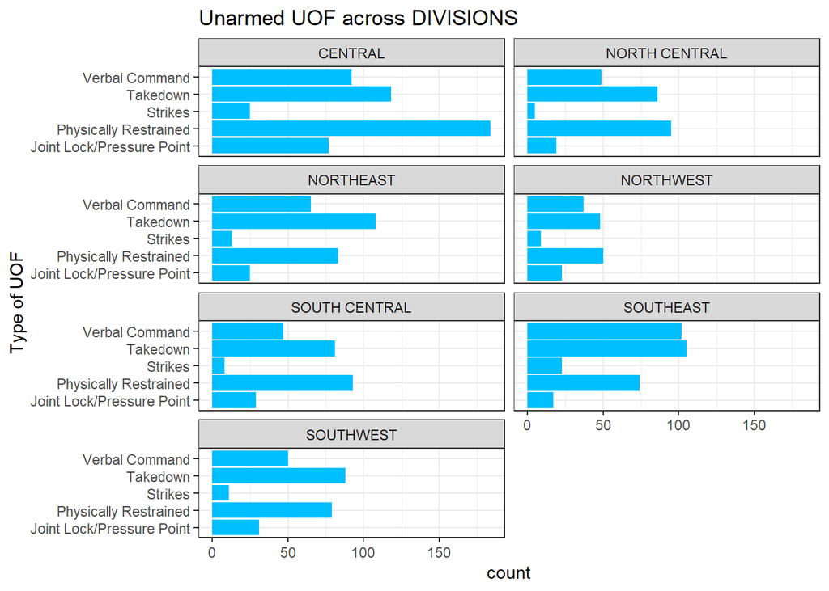

From the map and bar plot above we can see that for Verbal Command it is most common in the city centre and eastern divisions (NORTHEAST and SOUTHEAST). For Takedown it is also similarly most common in the city centre and eastern divisions (NORTHEAST and SOUTHEAST). For Strikes it is more evenly distributed across the city with a small increase in the city centre. For Physically Restrained it is most concentrated in the city centre with more in the eastern divisions than the west (NORTHEAST and SOUTHEAST). For Joint Lock/Pressure Point it is most common in the city centre and being evenly distributed outside the central divisions.

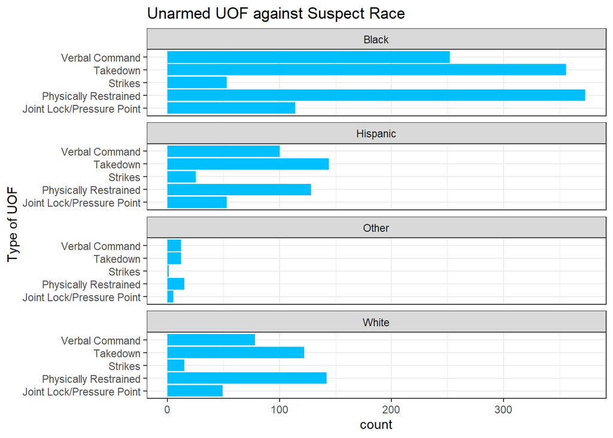

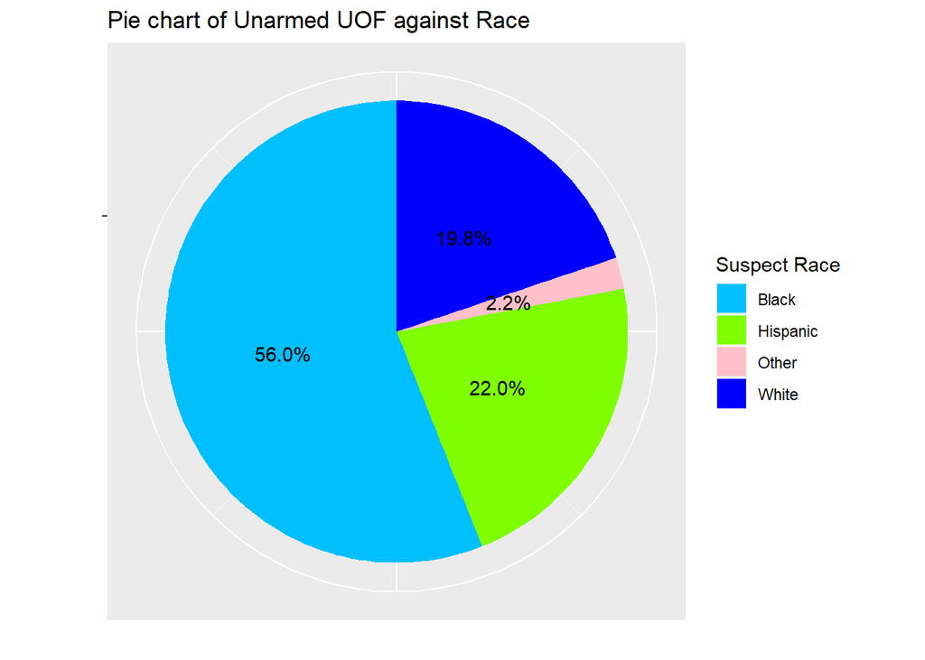

From the bar plot above we can see that Black suspects have the highest count of every Unarmed UOF tactic with Hispanic and White suspects having similar amounts. From the pie chart above we can see that black suspects have proportionally the highest count of Unarmed UOF incidents at 56% with Hispanic and White suspects at 22% and 19.8% respectively.

[interactive chart not shown]

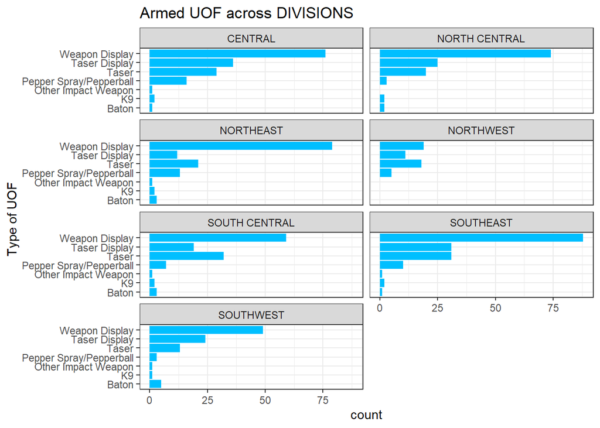

We can look at the different reasons for Armed UOF tactics for Weapon Display, Taser and Pepper Spray/Pepperball and plotting the against different variables.

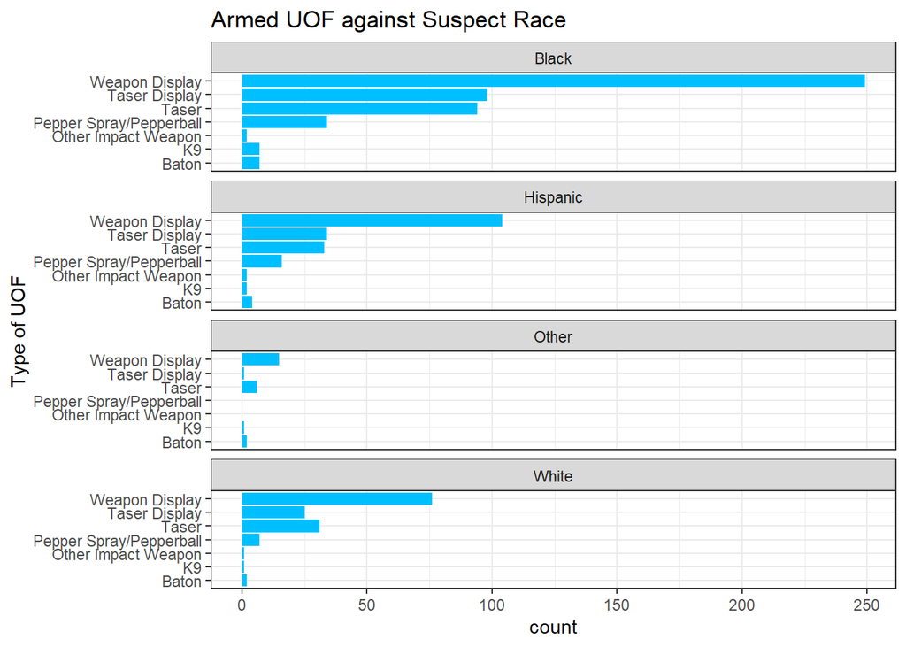

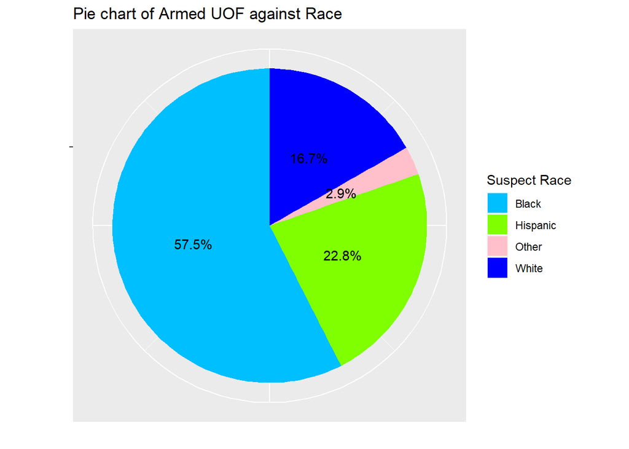

From the bar plot above we can see that Black suspects have by far the highest count of Weapon Display with Hispanic and White suspects in second and third place respectively. Similarly for Taser Black suspects have the highest count with Hispanic suspects in second being closely followed by White suspects. For Pepper Spray/Pepperball the pattern is still the same with Black suspects having the highest count and Hispanic and White suspects taking second and third place. From the pie chart above we can also see that Black suspects have proportionally the highest count of Armed UOF incidents at 57.5% followed by Hispanic and White suspects at 22.8% and 16.7% respectively.

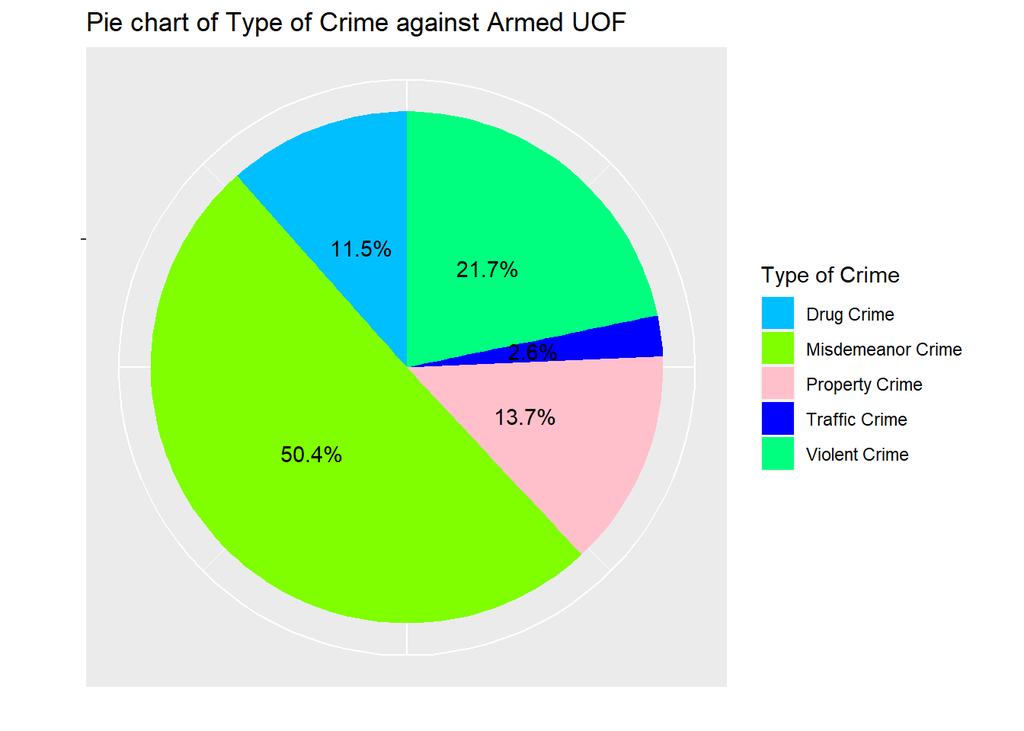

From the pie chart above we can see that Misdemeanor Crime makes up the most of Armed UOF incidents at 50.4% with Violent Crime in second place at 21.7% and Property Crime in third place 13.7% and Drug Crime in fourth place at 11.5% and lastly Traffic Crime in last place at 2.6%.

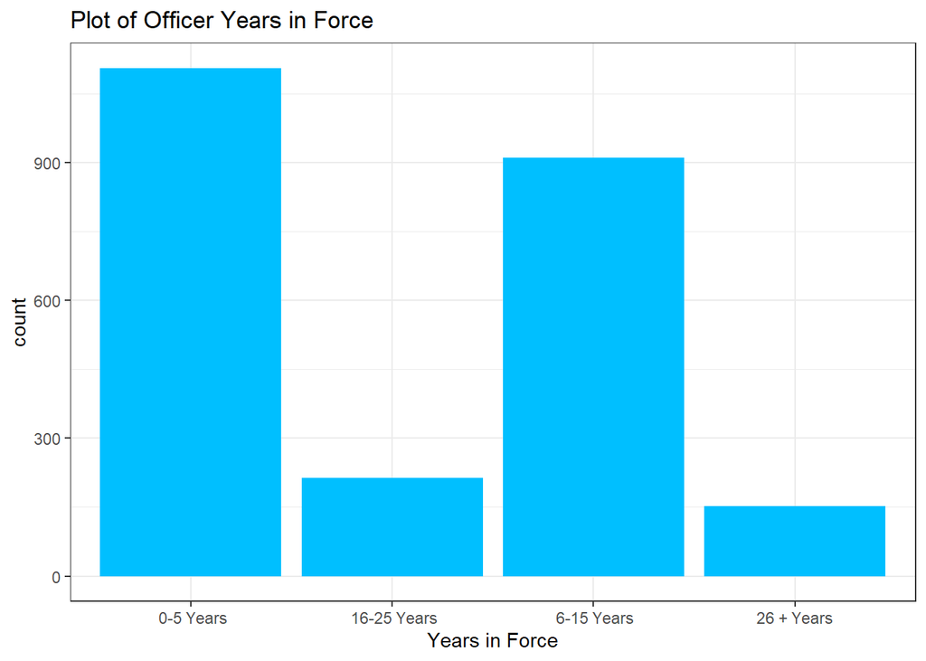

From the bar plot above we can see that majority of police officers have been in the force for 0-5 years and 6-15 years with the minority only having 16+ years in the force.

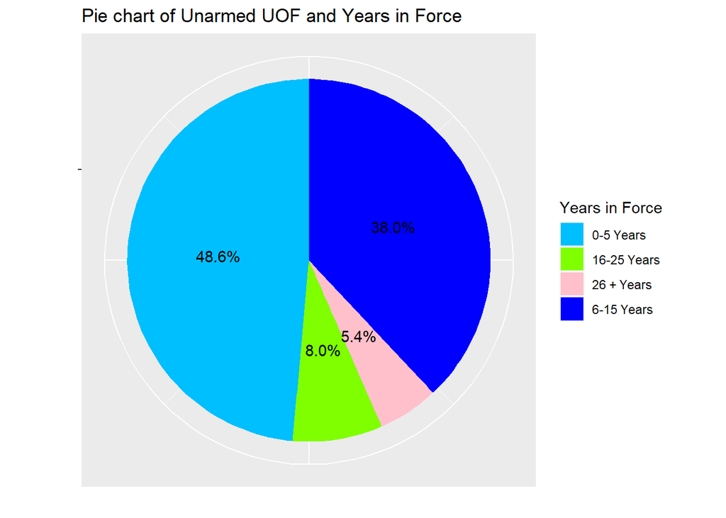

From the pie chart above we can see that officers that were in the police force for 0-5 years and 6-15 years have proportionally the highest count of Unarmed UOF incidents with officers that were in the force for 16 + years having considerably less.

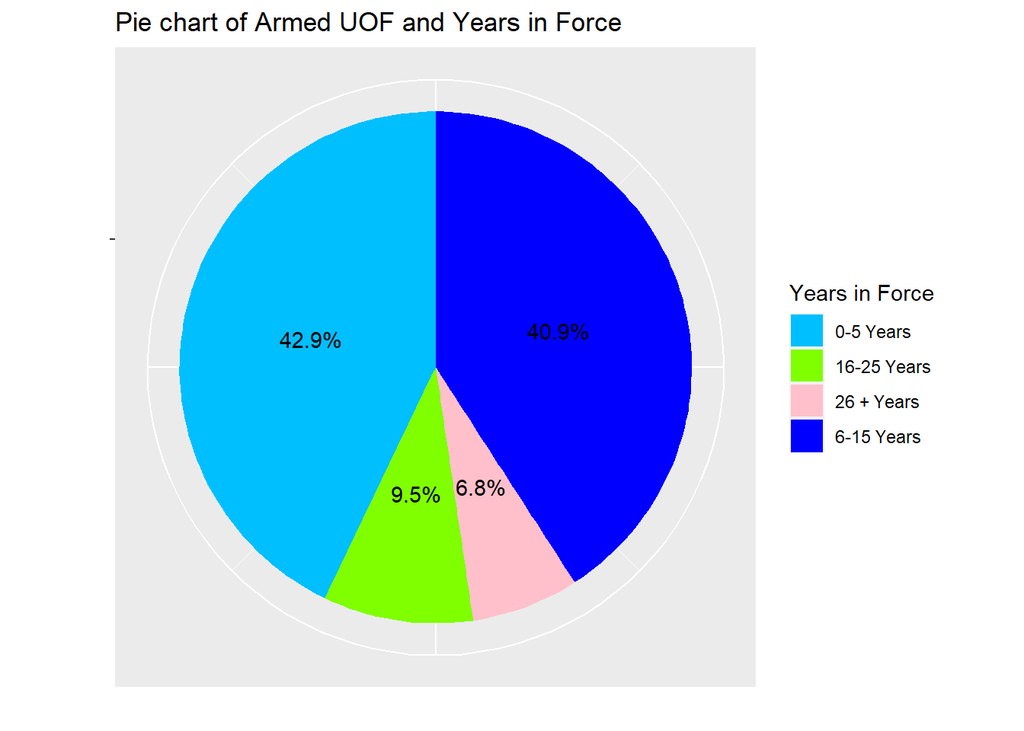

From the pie chart above we can see that officers that have been in the police force for 0-5 years and 6-15 years have proportionally the highest count of Armed UOF incidents with officers that were in the force for 16 + years having considerably less.

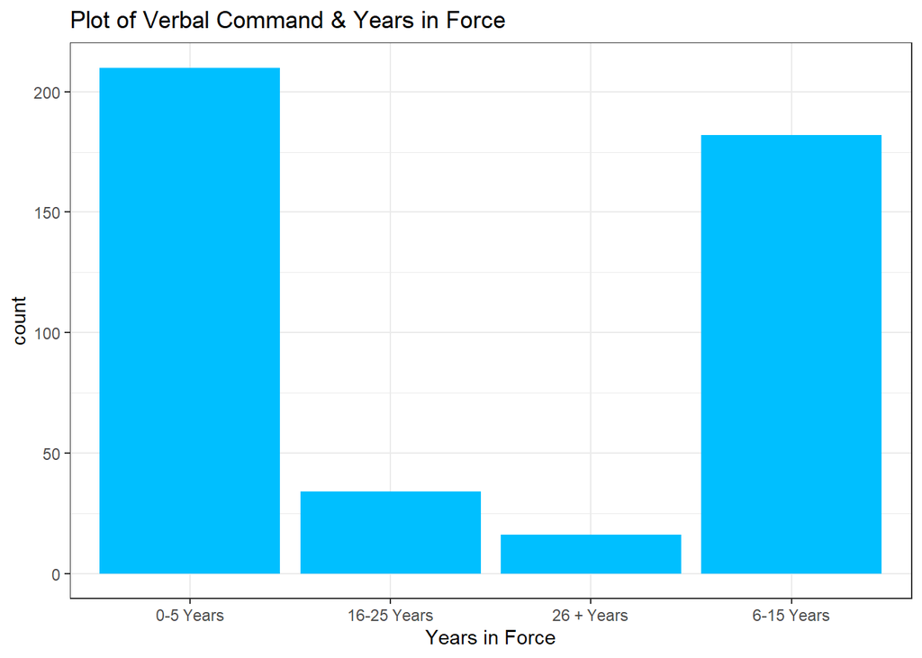

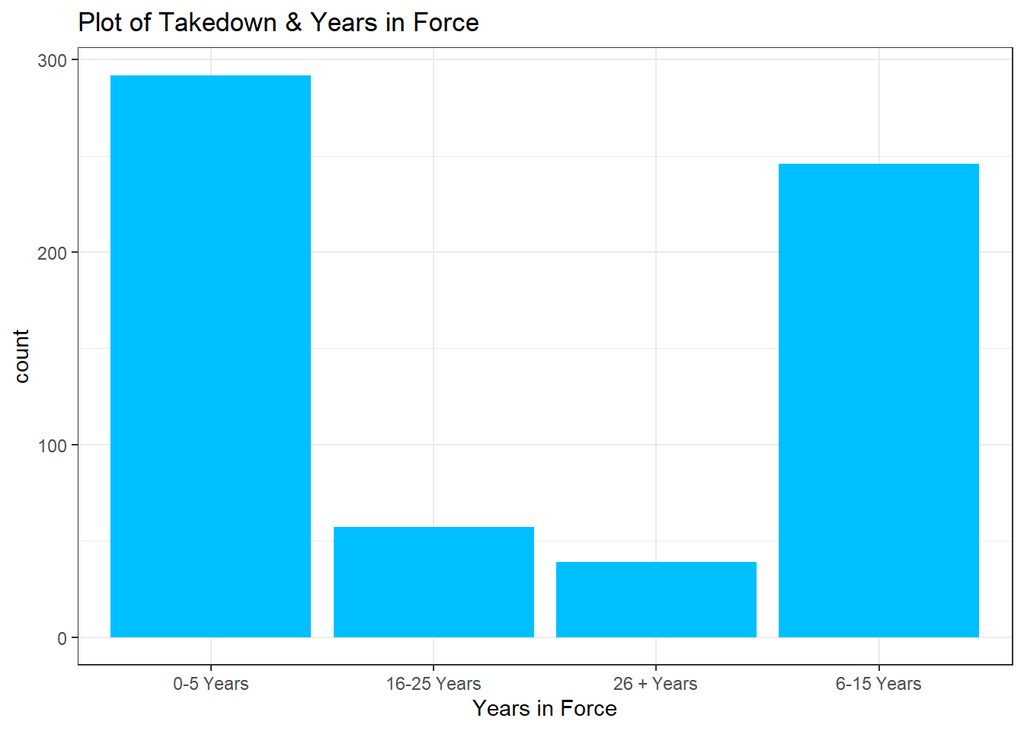

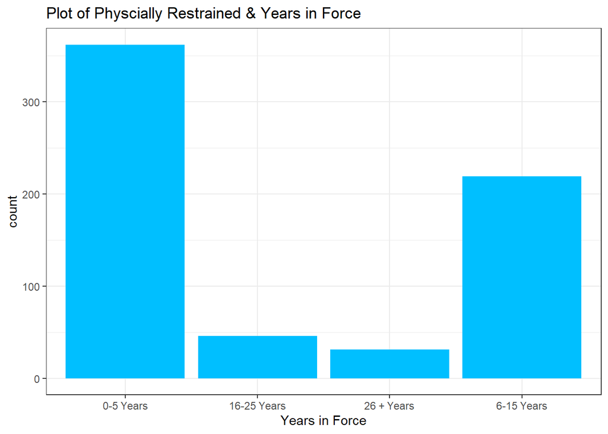

From the bar plots above we can see that for the different Unarmed UOF tactics and incident count that less experienced officers have higher (<15 years) have considerably higher counts of incidents compared to their more experienced counterparts (16 + years).

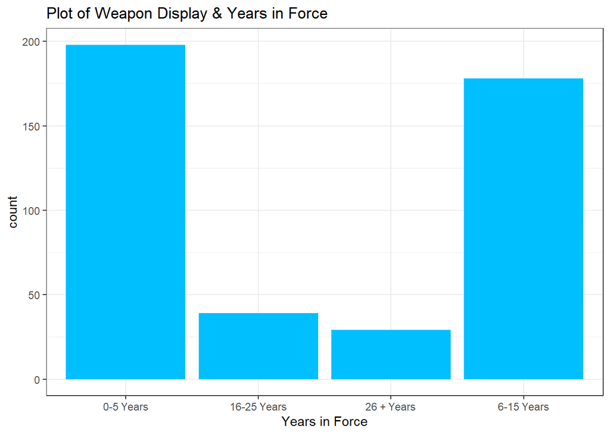

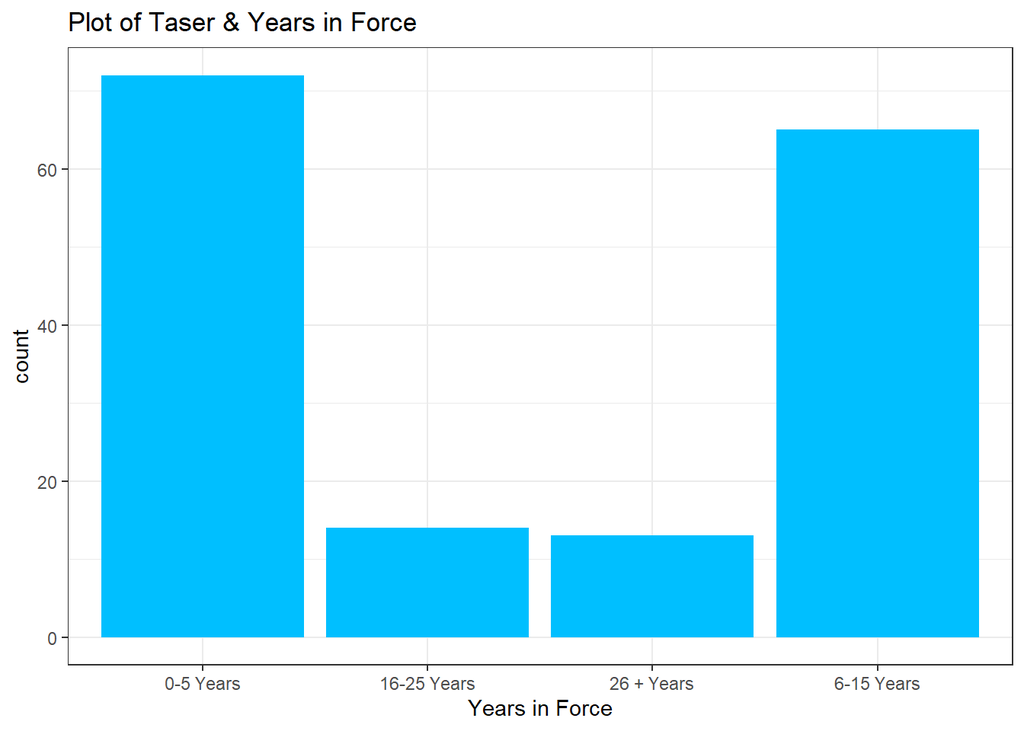

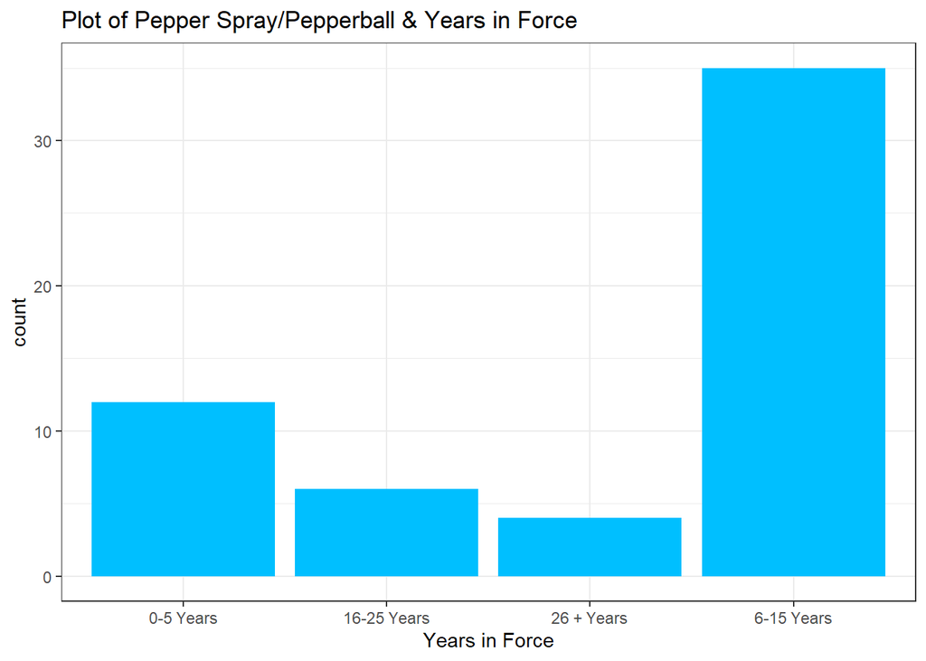

From the bar plots above we can see a similar trend to Unarmed UOF incidents where officers that have been in the force for less periods of time have higher incident counts for Armed UOF Tactics which you can see above for Weapon Display, Taser and Pepper Spray/Pepperball.

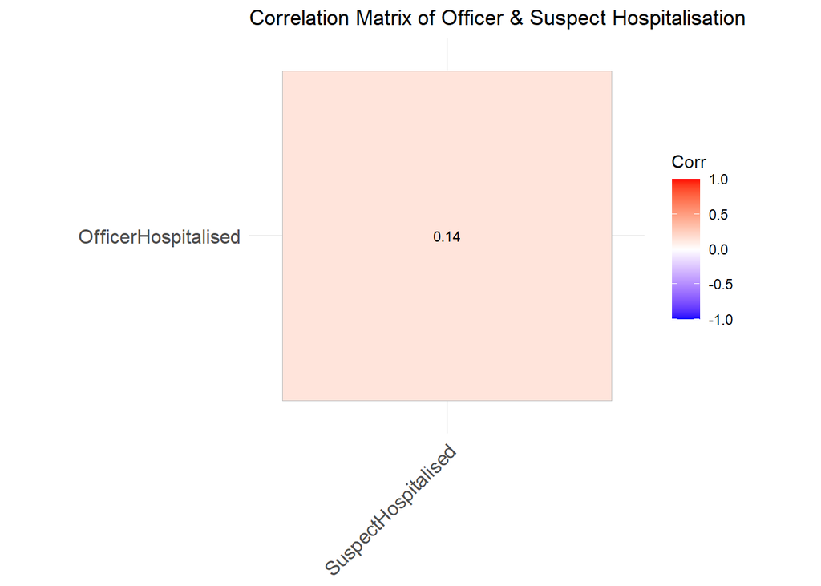

From the plot above we can see that the correlation between officers and suspects getting hospitalised is at a value of 0.14 which suggests that there is little to no correlation to officers and suspects being hospitalised.

# Summary of Findings

## Preliminary Findings

In the preliminary findings we find that in the data set there are considerably more black suspects having incidents with the police and being arrested in greater numbers compared to other races. With the frequency of incidents with police decreasing throughout the year and that the majority of the police force is made up of males officers who are predominantly white. We can also see the the rates of crime in Dallas for the different types of crime.

## A Closer Look at Crime in Dallas

From the different categories of crime in Dallas we are able to see their different rates and locations and analyse them against different factors such as race, month and hour.

### Violent Crime

The most frequent case of Violent Crime in Dallas was Domestic Violence and Assault mostly taking place in central Dallas and in the outskirts and city centre. Black suspects were proportionally the biggest perpetrators of Violent Crime who were then followed by Hispanic then White suspects. From the time series plots we are able to tell that Assault and Domestic Violence most occur late at night and in the evening and being most frequent near the beginning of the year in February and March.

### Drug Crime

The most frequent case of Drug Crime in Dallas was Drug Possession which was mostly taking place in the city centre and eastern parts of Dallas. Black suspects were proportionally the biggest perpetrators of Drug Crime who were then followed by Hispanic and White suspects. From the time series plots we are able to tell that Drug Possession occurs most late at night and in the evening and being most frequent near the beginning of the year in February.

### Property Crime

The most frequent case of Property Crime in Dallas was Trespassing which was mostly taking place in central Dallas and in the eastern parts of the city. Black suspects were proportionally the biggest perpetrators of Property Crime in Dallas who were then followed by White and Hispanic suspects. From the time series plots we are able to tell that Trespassing occurs most in the evening and in the afternoon and that it is most frequent in spring in March.

### Traffic Crime

The most frequent case of Traffic Crime in Dallas was DUI/DWI which was mostly taking place in central Dallas and in the western regions of the city. Black suspects were proportionally the biggest perpetrators of Traffic Crime in Dallas who were then followed by Hispanic and White suspects. From the time series plots we are able to tell that DUI/DWI occurs most late at night and in the evening and that it is most frequent in summer in June.

### Misdemeanor Crime

The most frequent case of Misdemeanor Crime in Dallas was Evading/Resisting Arrest which was mostly taking place in the city centre. Black suspects were proportionally the biggest perpetrators of Misdemeanor Crime in Dallas who were then followed by White and Hispanic suspects. From the time series plots we are able to tell that fact that Evading/Resisting Arrest occurs most in the evening and late at night and that it is most frequent in March.

## Discrimination in Policing

The biggest suspect description was Mentally Unstable and faceting it against whether suspects were arrested or not we can see that for those that were not arrested the biggest description was None Detected. Pairing this information with INCIDENT_REASON we can see that for those that were not arrested the biggest incident reason was a Service Call. Looking more closely into Service Call and breaking it down by race we can see that Black suspects we can see that Black suspects have the highest count of Service Call incidents followed by Hispanic and White suspects being tied second. Due to the fact citizens make the service calls to the police it is hard to discern whether there is potential discrimination since suspects would be arrested or not arrested whether or not they committed a crime.

On the other hand we can take a closer look at Pedestrian Stops and Traffic Stops to see if there is any potential discrimination. From the pie charts we are able to see that Black suspects go through Pedestrian and Traffic Stops proportionally more compared to other races. Looking more specifically to suspects that were searched but not arrested we can still see that Black suspects still have gone through more Traffic and Pedestrian Stops compared to other races. However, there is not enough data in the data set to determine whether this is racially motivated.

## Use of Force Incidents in Dallas

From the bar plots we can see that the biggest type of Unarmed UOF was Physically Restrained and the biggest type of Armed UOF was Weapon Display. The biggest Reason For Force was Arrest. Using the maps we can see that the UOF tactic Physically Restrained was most common in the city centre and in the eastern regions of the city. For the Armed UOF tactic Weapon Display we can see that it is most common in the city centre and in the eastern regions of the city. For both Armed and Unarmed UOF Black suspects have proportionally the biggest count of incidents followed by Hispanic and White suspects.

From the bar plot we can see that majority of police officers in Dallas have been in the force for less than 15 years. Using the pie charts we can see that the officers who have been in the force for less than 15 years have higher Armed and Unarmed UOF incidents compared to officers who were in the force for 16 + years. This can suggest that the more experienced officers know how to deal with suspects with less UOF tactics compared to the officers who have less experience although there is a lack of data to confirm this.

From the correlation matrix we can see that there is a weak correlation between officers getting hospitalised and suspects being hospitalised.